# Clean-Eating in Manhattan

### Exploring Vegetarian-friendly Restaurants and Neighborhoods

Haoran Zhang  
September, 2019

[figure not shown]

### Part 1: The Popularity of the Vegetarian Diet

In the past decades, people who identify themselves as vegetarian, vegan, or plant-based were viewed as weird and deficient in nutrition. Until the first decade of the 21st century, references to vegetarian eating in social media were often negative. The society is afraid of this plant-based lifestyle.

But now, all that has been changing. Diets that exclude meat, milk, and eggs are recognized as fads. From celebrities to the middle class, this clean-eating diet becomes popular among people. Eating clean is not limited to live a healthier life. Instead, it becomes a movement in an overall generation. Healthy cuisines, colorful ingredients, and lovely photos on Instagram, which could be reasons that people are trying to shift their consuming. According to a report by research firm GlobalData, here’s been a 600% increase in people identifying as vegans in the U.S in the last three years. Only 1% of U.S. consumers claimed to be vegan in 2014. And in 2017, that number rose to 6%. Even Walmart, the world’s largest retailer, is asking its suppliers to offer more plant-based products.

Beyond losing weight and keeping slim, the clean-eating diet has become a fashion among people, especially among millennials. This project will focus on the clean-eating restaurants in New York City: where to go for more vegetarian-friendly restaurants? Where to go for vegetarian-friendly restaurants with the highest rating score? Where to go for a “luxury” clean-eating meal? Let’s choose the “best” vegetarian-friendly restaurant and eat clean together.

```python
# API:
# Using Yelp API to get Vegetarian-Friendly Restaurant in Manhattan, NY
```

```python
import requests
import json
import pandas as pd
from pandas import Series,DataFrame
from PIL import Image
```

```python
api_key='zZSn4-1HB7uE283qQHcXlkJMI8xJGry3i9c9vgWn1--Ljd_twt6T2gokat5bpXXaWJVXjXthxRtR1JP5MsLQjo3I5n4TOcYyblHWAZ4x2GbtM0MGZaZ94l_M60uaXXYx'
headers = {'Authorization': 'Bearer %s' % api_key}
```

```python
url='https://api.yelp.com/v3/businesses/search'
params = {'term':'Vegetarian Friendly','location':'Manhattan, NY','limit':50}
```

```python
req=requests.get(url, params=params, headers=headers)

# proceed only if the status code is 200
print('The status code is {}'.format(req.status_code))
```

```
The status code is 200
```

```python
js = json.loads(req.text)
```

```python
js.keys()
```

```
dict_keys(['businesses', 'total', 'region'])
```

```python
type(js['businesses'][0])
```

```
dict
```

```python
pd.DataFrame.from_dict(js['businesses'])
df = pd.DataFrame.from_dict(js['businesses'])
df.head()
```

|  | alias | categories | coordinates | display_phone | distance | id | image_url | is_closed | location | name | phone | price | rating | review_count | transactions | url |
| --- | --- | --- | --- | --- | --- | --- | --- | --- | --- | --- | --- | --- | --- | --- | --- | --- |
| 0 | jajaja-new-york | [{'alias': 'mexican', 'title': 'Mexican'}, {'a... | {'latitude': 40.7141530317142, 'longitude': -7... | (646) 883-5453 | 5219.447624 | XipQLDbyTl5tsLlyzAWzug | https://s3-media1.fl.yelpcdn.com/bphoto/6HT76T... | False | {'address1': '162 E Broadway', 'address2': '',... | Jajaja | +16468835453 | $$ | 4.5 | 920 | [pickup, delivery, restaurant_reservation] | https://www.yelp.com/biz/jajaja-new-york?adjus... |
| 1 | anytime-new-york | [{'alias': 'korean', 'title': 'Korean'}, {'ali... | {'latitude': 40.74779, 'longitude': -73.98674} | (646) 669-7733 | 1534.173041 | VvsZAnEwU4c8Xkyrzx05Nw | https://s3-media3.fl.yelpcdn.com/bphoto/S-K4D4... | False | {'address1': '23 W 32nd St', 'address2': 'Fl 3... | Anytime | +16466697733 | $$ | 4.5 | 1381 | [restaurant_reservation] | https://www.yelp.com/biz/anytime-new-york?adju... |
| 2 | spicy-moon-east-village-new-york | [{'alias': 'szechuan', 'title': 'Szechuan'}, {... | {'latitude': 40.72674, 'longitude': -73.98722} | (646) 429-8471 | 3798.107378 | Bb0h5Rs8ugSM2CjulRhfBw | https://s3-media3.fl.yelpcdn.com/bphoto/5xj4Zy... | False | {'address1': '328 E 6th St', 'address2': '', '... | Spicy Moon East Village | +16464298471 | $$ | 4.5 | 291 | [pickup, delivery, restaurant_reservation] | https://www.yelp.com/biz/spicy-moon-east-villa... |
| 3 | xyst-new-york-2 | [{'alias': 'vegan', 'title': 'Vegan'}, {'alias... | {'latitude': 40.73874, 'longitude': -73.99444} | (212) 727-2979 | 2748.185852 | h0PVO3fYw37f7VUH4UA3jQ | https://s3-media4.fl.yelpcdn.com/bphoto/t6G5Wv... | False | {'address1': '44 West 17th St', 'address2': No... | XYST | +12127272979 | $$ | 4.0 | 329 | [restaurant_reservation] | https://www.yelp.com/biz/xyst-new-york-2?adjus... |
| 4 | p-s-kitchen-new-york-3 | [{'alias': 'vegetarian', 'title': 'Vegetarian'... | {'latitude': 40.76066, 'longitude': -73.98664} | (212) 651-7247 | 686.539180 | KXD44wWmrGf7mzyyr0bikw | https://s3-media2.fl.yelpcdn.com/bphoto/6h3Jkw... | False | {'address1': '246 W 48th St', 'address2': '', ... | P.S. Kitchen | +12126517247 | $$ | 4.0 | 446 | [pickup, delivery] | https://www.yelp.com/biz/p-s-kitchen-new-york-... |

```python
params = {'term':'Vegetarian Friendly','location':'Manhattan, NY','limit':50,'offset':50}
```

```python
req=requests.get(url, params=params, headers=headers)
```

```python
res = pd.DataFrame()
for i in range(20): # select 20 pages in total 1000 restaurant because the api will reject when offset > 1000
    params = {'term':'Vegetarian Friendly','location':'Manhattan, NY','limit':50,'offset':i*50}
    req=requests.get(url, params=params, headers=headers)
    js_tmp = json.loads(req.text)
    df_tmp = pd.DataFrame.from_dict(js_tmp['businesses'])
    res = pd.concat([res,df_tmp],axis = 0)
```

```python
res.head()
```

|  | alias | categories | coordinates | display_phone | distance | id | image_url | is_closed | location | name | phone | price | rating | review_count | transactions | url |
| --- | --- | --- | --- | --- | --- | --- | --- | --- | --- | --- | --- | --- | --- | --- | --- | --- |
| 0 | jajaja-new-york | [{'alias': 'mexican', 'title': 'Mexican'}, {'a... | {'latitude': 40.7141530317142, 'longitude': -7... | (646) 883-5453 | 5219.447624 | XipQLDbyTl5tsLlyzAWzug | https://s3-media1.fl.yelpcdn.com/bphoto/6HT76T... | False | {'address1': '162 E Broadway', 'address2': '',... | Jajaja | +16468835453 | $$ | 4.5 | 920 | [delivery, restaurant_reservation, pickup] | https://www.yelp.com/biz/jajaja-new-york?adjus... |
| 1 | anytime-new-york | [{'alias': 'korean', 'title': 'Korean'}, {'ali... | {'latitude': 40.74779, 'longitude': -73.98674} | (646) 669-7733 | 1534.173041 | VvsZAnEwU4c8Xkyrzx05Nw | https://s3-media3.fl.yelpcdn.com/bphoto/S-K4D4... | False | {'address1': '23 W 32nd St', 'address2': 'Fl 3... | Anytime | +16466697733 | $$ | 4.5 | 1381 | [restaurant_reservation] | https://www.yelp.com/biz/anytime-new-york?adju... |
| 2 | spicy-moon-east-village-new-york | [{'alias': 'szechuan', 'title': 'Szechuan'}, {... | {'latitude': 40.72674, 'longitude': -73.98722} | (646) 429-8471 | 3798.107378 | Bb0h5Rs8ugSM2CjulRhfBw | https://s3-media3.fl.yelpcdn.com/bphoto/5xj4Zy... | False | {'address1': '328 E 6th St', 'address2': '', '... | Spicy Moon East Village | +16464298471 | $$ | 4.5 | 291 | [delivery, restaurant_reservation, pickup] | https://www.yelp.com/biz/spicy-moon-east-villa... |
| 3 | xyst-new-york-2 | [{'alias': 'vegan', 'title': 'Vegan'}, {'alias... | {'latitude': 40.73874, 'longitude': -73.99444} | (212) 727-2979 | 2748.185852 | h0PVO3fYw37f7VUH4UA3jQ | https://s3-media4.fl.yelpcdn.com/bphoto/t6G5Wv... | False | {'address1': '44 West 17th St', 'address2': No... | XYST | +12127272979 | $$ | 4.0 | 329 | [restaurant_reservation] | https://www.yelp.com/biz/xyst-new-york-2?adjus... |
| 4 | p-s-kitchen-new-york-3 | [{'alias': 'vegetarian', 'title': 'Vegetarian'... | {'latitude': 40.76066, 'longitude': -73.98664} | (212) 651-7247 | 686.539180 | KXD44wWmrGf7mzyyr0bikw | https://s3-media2.fl.yelpcdn.com/bphoto/6h3Jkw... | False | {'address1': '246 W 48th St', 'address2': '', ... | P.S. Kitchen | +12126517247 | $$ | 4.0 | 446 | [delivery, pickup] | https://www.yelp.com/biz/p-s-kitchen-new-york-... |

```python
res.shape
```

```
(1000, 16)
```

got 1000 restaurants data from Yelp API, with attributes like name, categories, coordinates, phone number, price, rating, review, etc.

```python
# Clean the data and get ".csv"
```

```python
tmp1 = pd.DataFrame.from_dict(res)
```

```python
for biz in js_tmp['businesses'][0:5]:
    print(biz['location'])
```

```
{'address1': '60 2nd Ave', 'address2': '', 'address3': '', 'city': 'New York', 'zip_code': '10003', 'country': 'US', 'state': 'NY', 'display_address': ['60 2nd Ave', 'New York, NY 10003']}
{'address1': '480 Madison St', 'address2': None, 'address3': '', 'city': 'Brooklyn', 'zip_code': '11221', 'country': 'US', 'state': 'NY', 'display_address': ['480 Madison St', 'Brooklyn, NY 11221']}
{'address1': '123 W 52nd St', 'address2': '', 'address3': '', 'city': 'New York', 'zip_code': '10019', 'country': 'US', 'state': 'NY', 'display_address': ['123 W 52nd St', 'New York, NY 10019']}
{'address1': '28 Cornelia St', 'address2': '', 'address3': '', 'city': 'New York', 'zip_code': '10014', 'country': 'US', 'state': 'NY', 'display_address': ['28 Cornelia St', 'New York, NY 10014']}
{'address1': '601 W 57th St', 'address2': '', 'address3': None, 'city': 'New York', 'zip_code': '10019', 'country': 'US', 'state': 'NY', 'display_address': ['601 W 57th St', 'New York, NY 10019']}
```

```python
def find_latitude(dic):
    return dic['latitude']
def find_longitude(dic):
    return dic['longitude']
```

```python
df_lat = tmp1.coordinates.apply(find_latitude)
df_lat.head()
```

```
0    40.714153
1    40.747790
2    40.726740
3    40.738740
4    40.760660
Name: coordinates, dtype: float64
```

```python
df_lon = tmp1.coordinates.apply(find_longitude)
df_lon.head()
```

```
0   -73.990425
1   -73.986740
2   -73.987220
3   -73.994440
4   -73.986640
Name: coordinates, dtype: float64
```

```python
def find_zip(dic):
    return dic['zip_code']
df_zip = tmp1.location.apply(find_zip)
df_zip.head()
```

```
0    10002
1    10001
2    10003
3    10011
4    10036
Name: location, dtype: object
```

```python
res['latitude'] = tmp1.coordinates.apply(find_latitude)
res['longitude'] = tmp1.coordinates.apply(find_longitude)
res['zipcode'] = tmp1.location.apply(find_zip)
res = res[['name','latitude','longitude','zipcode','price','rating','review_count']]
res.head()
```

|  | name | latitude | longitude | zipcode | price | rating | review_count |
| --- | --- | --- | --- | --- | --- | --- | --- |
| 0 | Jajaja | 40.714153 | -73.990425 | 10002 | $$ | 4.5 | 920 |
| 1 | Anytime | 40.747790 | -73.986740 | 10001 | $$ | 4.5 | 1381 |
| 2 | Spicy Moon East Village | 40.726740 | -73.987220 | 10003 | $$ | 4.5 | 291 |
| 3 | XYST | 40.738740 | -73.994440 | 10011 | $$ | 4.0 | 329 |
| 4 | P.S. Kitchen | 40.760660 | -73.986640 | 10036 | $$ | 4.0 | 446 |

```python
res.to_csv('Yelp_Vege_Friendly_M_selected.csv')
df=pd.read_csv('Yelp_Vege_Friendly_M_selected.csv', index_col=0)
df.head()
```

|  | name | latitude | longitude | zipcode | price | rating | review_count |
| --- | --- | --- | --- | --- | --- | --- | --- |
| 0 | Jajaja | 40.714153 | -73.990425 | 10002 | $$ | 4.5 | 920 |
| 1 | Anytime | 40.747790 | -73.986740 | 10001 | $$ | 4.5 | 1381 |
| 2 | Spicy Moon East Village | 40.726740 | -73.987220 | 10003 | $$ | 4.5 | 291 |
| 3 | XYST | 40.738740 | -73.994440 | 10011 | $$ | 4.0 | 329 |
| 4 | P.S. Kitchen | 40.760660 | -73.986640 | 10036 | $$ | 4.0 | 446 |

```python
import numpy as np
import seaborn as sns
import matplotlib.pyplot as plt
```

```python
df['price'].unique()
```

```
array(['$$', nan, '$$$', '$', '$$$$'], dtype=object)
```

```python
Count_price = df['price'].value_counts()
Count_price
```

```
$$      706
$$$     119
$        46
$$$$     17
Name: price, dtype: int64
```

For the price, most clean-eating restaurants are within $$, which means that in NYC, they are affordable but not so cheap.

```python
price_dictionary ={'$':1,'$$' : 2, '$$$' : 3,'$$$$':4}
df['Price_num'] = df['price'].map(price_dictionary)
df.head()
```

|  | name | latitude | longitude | zipcode | price | rating | review_count | Price_num |
| --- | --- | --- | --- | --- | --- | --- | --- | --- |
| 0 | Jajaja | 40.714153 | -73.990425 | 10002 | $$ | 4.5 | 920 | 2.0 |
| 1 | Anytime | 40.747790 | -73.986740 | 10001 | $$ | 4.5 | 1381 | 2.0 |
| 2 | Spicy Moon East Village | 40.726740 | -73.987220 | 10003 | $$ | 4.5 | 291 | 2.0 |
| 3 | XYST | 40.738740 | -73.994440 | 10011 | $$ | 4.0 | 329 | 2.0 |
| 4 | P.S. Kitchen | 40.760660 | -73.986640 | 10036 | $$ | 4.0 | 446 | 2.0 |

```python
df.dropna(inplace=True)
```

```python
df.duplicated(subset = None, keep = 'first')
df.shape
```

```
(888, 8)
```

```python
df.head()
```

|  | name | latitude | longitude | zipcode | price | rating | review_count | Price_num |
| --- | --- | --- | --- | --- | --- | --- | --- | --- |
| 0 | Jajaja | 40.714153 | -73.990425 | 10002 | $$ | 4.5 | 920 | 2.0 |
| 1 | Anytime | 40.747790 | -73.986740 | 10001 | $$ | 4.5 | 1381 | 2.0 |
| 2 | Spicy Moon East Village | 40.726740 | -73.987220 | 10003 | $$ | 4.5 | 291 | 2.0 |
| 3 | XYST | 40.738740 | -73.994440 | 10011 | $$ | 4.0 | 329 | 2.0 |
| 4 | P.S. Kitchen | 40.760660 | -73.986640 | 10036 | $$ | 4.0 | 446 | 2.0 |

```python
df['zipcode'].unique()
```

```
array([10002, 10001, 10003, 10011, 10036, 10016, 10013, 10018, 10017,
       10019, 10014, 10009, 10012, 10065, 10103, 10021, 10030, 10025,
       10024, 10023, 10020, 10028, 10022, 11211, 10010, 10029, 10038,
       10005, 10026, 10007, 11231, 10128, 10032, 10075, 11205, 11237,
       10158, 11372,  7030, 10027, 11238, 11373, 10035, 11217, 10169,
       10039, 10033, 10304, 11105, 11206, 10004, 11201, 11385, 11215,
       11377, 10031, 11101, 11222, 10006, 11218,  7302, 11354, 11249,
       11106, 11103, 10460, 10118, 11225, 10270, 11221, 10111, 10280,
       11355, 10281, 11375,  7022, 11216,  7093,  7666], dtype=int64)
```

```python
df = df[df.zipcode.isin(['10026','10027', '10030', '10037','10039','10001','10011','10018','10019', '10020','10036','10029','10035','10010','10016','10017','10022',
                    '10012', '10013','10014','10004','10005','10006','10007','10038','10280','10002','10003','10009','10021','10028','10044','10065','10075',
                    '10128','10023','10024','10025','10031','10032','10033','10034','10040'])]
df.head()
```

|  | name | latitude | longitude | zipcode | price | rating | review_count | Price_num |
| --- | --- | --- | --- | --- | --- | --- | --- | --- |
| 0 | Jajaja | 40.714153 | -73.990425 | 10002 | $$ | 4.5 | 920 | 2.0 |
| 1 | Anytime | 40.747790 | -73.986740 | 10001 | $$ | 4.5 | 1381 | 2.0 |
| 2 | Spicy Moon East Village | 40.726740 | -73.987220 | 10003 | $$ | 4.5 | 291 | 2.0 |
| 3 | XYST | 40.738740 | -73.994440 | 10011 | $$ | 4.0 | 329 | 2.0 |
| 4 | P.S. Kitchen | 40.760660 | -73.986640 | 10036 | $$ | 4.0 | 446 | 2.0 |

```python
df['zipcode'].unique()
```

```
array([10002, 10001, 10003, 10011, 10036, 10016, 10013, 10018, 10017,
       10019, 10014, 10009, 10012, 10065, 10021, 10030, 10025, 10024,
       10023, 10020, 10028, 10022, 10010, 10029, 10038, 10005, 10026,
       10007, 10128, 10032, 10075, 10027, 10035, 10039, 10033, 10004,
       10031, 10006, 10280], dtype=int64)
```

### Part 2: Exploring Vegetarian-friendly Restaurants in Manhattan

#### (1) Where to go for more vegetarian-friendly restaurants?

While searching “Vegetarian-friendly” in Manhattan, on the map, we can find that they are denser in part of Midtown and Downtown Manhattan. But which neighborhoods have more than others? Digging deep by using Yelp API with around 800 restaurants in Manhattan, top neighborhoods where people are easier to find vegetarian food/restaurants are highlighted: Clinton, East Village, Chelsea, and Murray Hill. If you are planning a vacation to New York City, and you also are a fan of healthy food, neighborhoods mentioned above can be ideal choices for a bite. Among the three, at Clinton and East Village, with various categories of dishes, including Mediterranean, Thai, Mexican, and Chinese cuisines, you’ll always find your best matching one. On the contrary, in Inwood, Washington Heights, and Central Harlem, finding vegetarian dishes might be more much difficult. In addition to the total number of “green” restaurants, rates by customers and price level are also important when you would like to find a wonderful eating place.

```python
#Distribution: Which neighborhoods(based on zipcode) have more vegetarian-friendly restaurants than others?
```

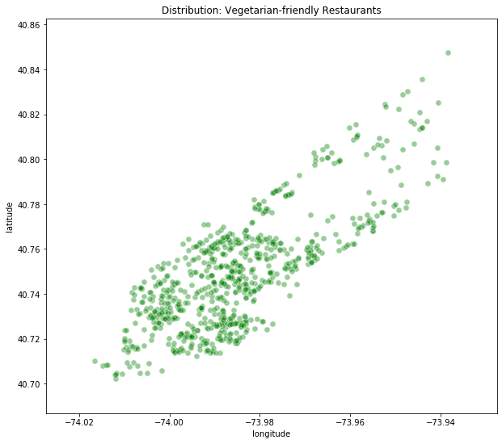

```python
#distribution
# plot the reduced set of coordinate points

fig, ax = plt.subplots()
fig.set_size_inches(10,9)
df_scatter = ax.scatter(df['longitude'], df['latitude'], c='g', edgecolor='w', alpha=0.4, s=50)

# set axis labels, tick labels, and title
ax.set_title('Distribution: Vegetarian-friendly Restaurants')
ax.set_xlabel('longitude')
ax.set_ylabel('latitude')

plt.show()
```

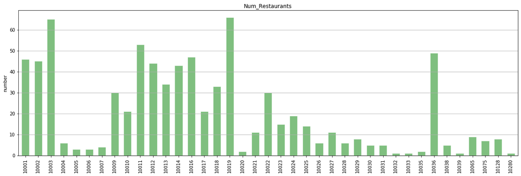

```python
Count_zipcode = df['zipcode'].value_counts().sort_index()
ax = Count_zipcode.plot(kind='bar', figsize=[20, 6], width=0.6, alpha=0.5, color='g', edgecolor='w', grid=False)

ax.yaxis.grid(True)

ax.set_title('Num_Restaurants')
ax.set_xlabel('')
ax.set_ylabel('number')

plt.show()
```

```python
Count_zipcode = df['zipcode'].value_counts()
Count_zipcode.head()
```

```
10019    66
10003    65
10011    53
10036    49
10016    47
Name: zipcode, dtype: int64
```

Central Harlem 10026, 10027, 10030, 10037, 10039  
Chelsea and Clinton 10001, 10011, 10018, 10019, 10020, 10036  
East Harlem 10029, 10035  
Gramercy Park and Murray Hill 10010, 10016, 10017, 10022  
Greenwich Village and Soho 10012, 10013, 10014  
Lower Manhattan 10004, 10005, 10006, 10007, 10038, 10280  
Lower East Side 10002, 10003, 10009  
Upper East Side 10021, 10028, 10044, 10065, 10075, 10128  
Upper West Side 10023, 10024, 10025  
Inwood and Washington Heights 10031, 10032, 10033, 10034, 10040

```python
# more VF restaurants than others: East Village (10003); Clinton Neighborhood, around Columbus Circles (10019)
```